# Bellabeat - Fitbit Fitness Tracker Data (Case Study)

Irvan Fauzan Syarif

06 Agustus 2023

## **Bellabeat Data Report**

### **Skenario**

Bellabeat adalah perusahaan produk berteknologi tinggi yang berfokus pada kesehatan untuk wanita. Meskipun Bellabeat sudah menjadi perusahaan kecil yang sukses, mereka memiliki potensi untuk menjadi pemain yang lebih besar di pasar perangkat pintar global. Cofounder dan Chief Creative Officer Bellabeat, Urška Sršen, percaya bahwa menganalisis data kebugaran perangkat pintar dapat membantu membuka peluang pertumbuhan baru bagi perusahaan. Sebagai seorang analis data junior yang bekerja di tim analis pemasaran di Bellabeat, Saya ditugaskan untuk fokus pada produk Bellabeat dan menganalisis data penggunaan perangkat pintar untuk mendapatkan wawasan tentang bagaimana pelanggan menggunakan perangkat pintar mereka. Kemudian, dengan menggunakan informasi ini, ia menginginkan rekomendasi tingkat tinggi tentang bagaimana tren ini dapat membantu penyusunan strategi pemasaran Bellabeat.

### **Tahap Bertanya (*Ask*)**

#### **Masalah apa yang Anda coba pecahkan?**

Salah satu pendiri Bellabeat, Urska Srsen, telah meminta tim analitik untuk fokus pada produk Bellabeat dan menganalisis data penggunaan perangkat pintar untuk mendapatkan wawasan tentang bagaimana orang sudah menggunakan perangkat pintar mereka. Dari data ini, Srsen menginginkan rekomendasi tingkat tinggi tentang bagaimana tren ini dapat menginformasikan strategi pemasaran Bellabeat.

#### **Bagaimana wawasan Anda dapat mendorong keputusan bisnis?**

Wawasan saya akan mengidentifikasi pola penggunaan perangkat pintar, dan berdasarkan informasi tersebut, saya akan memberikan rekomendasi khusus. Contohnya, saya akan menganalisis seberapa aktifnya populasi umum ketika beraktivitas dalam seminggu dan mengkategorikan tingkat aktivitas mereka dari yang terendah hingga teraktif.

#### **Tugas bisnis**

Fokus pada data penggunaan perangkat pintar, kemudian identifikasi tren yang mengarah pada rekomendasi tingkat tinggi yang dapat menginformasikan strategi pemasaran Bellabeat.

#### **Pemangku Kepentingan**

Anggota eksekutif Urška Sršen dan Sando Mur, serta tim analitik pemasaran Bellabeat.

### **Tahap Proses (*Process*)**

#### **Alat yang digunakan**

RStudio

#### **Proses *Load Package*, *Import* dan *Cleansing* data**

Mengatur R Environment untuk memuat paket:

```r
library(tidyverse)
library(skimr)
library(janitor)
library(dplyr)
library(lubridate)
library(readr)
library(tibble)
```

Kemudian mulai mengimport data:

```r
activity <- read_csv("C:/Users/VANFAUZAN/Documents/R/study_case/data_fitbit/dailyActivity_merged.csv")
sleep <- read_csv("C:/Users/VANFAUZAN/Documents/R/study_case/data_fitbit/sleepDay_merged.csv")
hourly_steps <- read_csv("C:/Users/VANFAUZAN/Documents/R/study_case/data_fitbit/hourlySteps_merged.csv")
calories_burned_perhour <- read_csv("C:/Users/VANFAUZAN/Documents/R/study_case/data_fitbit/hourlyCalories_merged.csv")
```

Pemeriksaan setiap *data frame* menggunakan fungsi str() / struktur:

```r
str(activity)
```

```
## spc_tbl_ [940 × 15] (S3: spec_tbl_df/tbl_df/tbl/data.frame)
##  $ Id                      : num [1:940] 1.5e+09 1.5e+09 1.5e+09 1.5e+09 1.5e+09 ...
##  $ ActivityDate            : chr [1:940] "4/12/2016" "4/13/2016" "4/14/2016" "4/15/2016" ...
##  $ TotalSteps              : num [1:940] 13162 10735 10460 9762 12669 ...
##  $ TotalDistance           : num [1:940] 8.5 6.97 6.74 6.28 8.16 ...
##  $ TrackerDistance         : num [1:940] 8.5 6.97 6.74 6.28 8.16 ...
##  $ LoggedActivitiesDistance: num [1:940] 0 0 0 0 0 0 0 0 0 0 ...
##  $ VeryActiveDistance      : num [1:940] 1.88 1.57 2.44 2.14 2.71 ...
##  $ ModeratelyActiveDistance: num [1:940] 0.55 0.69 0.4 1.26 0.41 ...
##  $ LightActiveDistance     : num [1:940] 6.06 4.71 3.91 2.83 5.04 ...
##  $ SedentaryActiveDistance : num [1:940] 0 0 0 0 0 0 0 0 0 0 ...
##  $ VeryActiveMinutes       : num [1:940] 25 21 30 29 36 38 42 50 28 19 ...
##  $ FairlyActiveMinutes     : num [1:940] 13 19 11 34 10 20 16 31 12 8 ...
##  $ LightlyActiveMinutes    : num [1:940] 328 217 181 209 221 164 233 264 205 211 ...
##  $ SedentaryMinutes        : num [1:940] 728 776 1218 726 773 ...
##  $ Calories                : num [1:940] 1985 1797 1776 1745 1863 ...
##  - attr(*, "spec")=
##   .. cols(
##   ..   Id = col_double(),
##   ..   ActivityDate = col_character(),
##   ..   TotalSteps = col_double(),
##   ..   TotalDistance = col_double(),
##   ..   TrackerDistance = col_double(),
##   ..   LoggedActivitiesDistance = col_double(),
##   ..   VeryActiveDistance = col_double(),
##   ..   ModeratelyActiveDistance = col_double(),
##   ..   LightActiveDistance = col_double(),
##   ..   SedentaryActiveDistance = col_double(),
##   ..   VeryActiveMinutes = col_double(),
##   ..   FairlyActiveMinutes = col_double(),
##   ..   LightlyActiveMinutes = col_double(),
##   ..   SedentaryMinutes = col_double(),
##   ..   Calories = col_double()
##   .. )
##  - attr(*, "problems")=<externalptr>
```

```r
str(sleep)
```

```
## spc_tbl_ [413 × 5] (S3: spec_tbl_df/tbl_df/tbl/data.frame)
##  $ Id                : num [1:413] 1.5e+09 1.5e+09 1.5e+09 1.5e+09 1.5e+09 ...
##  $ SleepDay          : chr [1:413] "4/12/2016 12:00:00 AM" "4/13/2016 12:00:00 AM" "4/15/2016 12:00:00 AM" "4/16/2016 12:00:00 AM" ...
##  $ TotalSleepRecords : num [1:413] 1 2 1 2 1 1 1 1 1 1 ...
##  $ TotalMinutesAsleep: num [1:413] 327 384 412 340 700 304 360 325 361 430 ...
##  $ TotalTimeInBed    : num [1:413] 346 407 442 367 712 320 377 364 384 449 ...
##  - attr(*, "spec")=
##   .. cols(
##   ..   Id = col_double(),
##   ..   SleepDay = col_character(),
##   ..   TotalSleepRecords = col_double(),
##   ..   TotalMinutesAsleep = col_double(),
##   ..   TotalTimeInBed = col_double()
##   .. )
##  - attr(*, "problems")=<externalptr>
```

```r
str(hourly_steps)
```

```
## spc_tbl_ [22,099 × 3] (S3: spec_tbl_df/tbl_df/tbl/data.frame)
##  $ Id          : num [1:22099] 1.5e+09 1.5e+09 1.5e+09 1.5e+09 1.5e+09 ...
##  $ ActivityHour: chr [1:22099] "4/12/2016 12:00:00 AM" "4/12/2016 1:00:00 AM" "4/12/2016 2:00:00 AM" "4/12/2016 3:00:00 AM" ...
##  $ StepTotal   : num [1:22099] 373 160 151 0 0 ...
##  - attr(*, "spec")=
##   .. cols(
##   ..   Id = col_double(),
##   ..   ActivityHour = col_character(),
##   ..   StepTotal = col_double()
##   .. )
##  - attr(*, "problems")=<externalptr>
```

```r
str(calories_burned_perhour)
```

```
## spc_tbl_ [22,099 × 3] (S3: spec_tbl_df/tbl_df/tbl/data.frame)
##  $ Id          : num [1:22099] 1.5e+09 1.5e+09 1.5e+09 1.5e+09 1.5e+09 ...
##  $ ActivityHour: chr [1:22099] "4/12/2016 12:00:00 AM" "4/12/2016 1:00:00 AM" "4/12/2016 2:00:00 AM" "4/12/2016 3:00:00 AM" ...
##  $ Calories    : num [1:22099] 81 61 59 47 48 48 48 47 68 141 ...
##  - attr(*, "spec")=
##   .. cols(
##   ..   Id = col_double(),
##   ..   ActivityHour = col_character(),
##   ..   Calories = col_double()
##   .. )
##  - attr(*, "problems")=<externalptr>
```

Pemeriksaan nilai duplikat pada data:

```r
sum(duplicated(activity))
```

```
## [1] 0
```

```r
sum(duplicated(sleep))
```

```
## [1] 3
```

```r
sum(duplicated(hourly_steps))
```

```
## [1] 0
```

```r
sum(duplicated(calories_burned_perhour))
```

```
## [1] 0
```

Menghapus nilai duplikat pada tabel *sleep*:

```r
sleep <- sleep[!duplicated(sleep), ]
```

Mengubah data yang memiliki format tanggal dan waktu:

```r
activity <- activity %>%
  rename(date = ActivityDate) %>%
  mutate(date = as_date(date, format = "%m/%d/%Y"))

sleep <- sleep %>%
  rename(date = SleepDay) %>%
  mutate(date = as_date(date,format ="%m/%d/%Y %I:%M:%S %p"))

hourly_steps <- hourly_steps %>%
  rename(date_time = ActivityHour ) %>%
  mutate(date_time = as.POSIXct(date_time, format ="%m/%d/%Y %I:%M:%S %p"))

calories_burned_perhour <- calories_burned_perhour %>%
  rename(date_time = ActivityHour ) %>%
  mutate(date_time = as.POSIXct(date_time, format = "%m/%d/%Y %I:%M:%S %p"))
```

Menambahkan kolom baru pada setiap tabel berdasarkan jumlah harii dalam 1 minggu:

```r
activity$day_of_week <- weekdays(activity$date)
sleep$day_of_week <- weekdays(sleep$date)
hourly_steps$day_of_week <- weekdays(hourly_steps$date_time)
calories_burned_perhour$day_of_week <- weekdays(calories_burned_perhour$date_time)
```

```r
head(activity)
```

```
## # A tibble: 6 × 16
##           Id date       TotalSteps TotalDistance TrackerDistance
##        <dbl> <date>          <dbl>         <dbl>           <dbl>
## 1 1503960366 2016-04-12      13162          8.5             8.5
## 2 1503960366 2016-04-13      10735          6.97            6.97
## 3 1503960366 2016-04-14      10460          6.74            6.74
## 4 1503960366 2016-04-15       9762          6.28            6.28
## 5 1503960366 2016-04-16      12669          8.16            8.16
## 6 1503960366 2016-04-17       9705          6.48            6.48
## # ℹ 11 more variables: LoggedActivitiesDistance <dbl>,
## #   VeryActiveDistance <dbl>, ModeratelyActiveDistance <dbl>,
## #   LightActiveDistance <dbl>, SedentaryActiveDistance <dbl>,
## #   VeryActiveMinutes <dbl>, FairlyActiveMinutes <dbl>,
## #   LightlyActiveMinutes <dbl>, SedentaryMinutes <dbl>, Calories <dbl>,
## #   day_of_week <chr>
```

```r
head(sleep)
```

```
## # A tibble: 6 × 6
##           Id date       TotalSleepRecords TotalMinutesAsleep TotalTimeInBed
##        <dbl> <date>                 <dbl>              <dbl>          <dbl>
## 1 1503960366 2016-04-12                 1                327            346
## 2 1503960366 2016-04-13                 2                384            407
## 3 1503960366 2016-04-15                 1                412            442
## 4 1503960366 2016-04-16                 2                340            367
## 5 1503960366 2016-04-17                 1                700            712
## 6 1503960366 2016-04-19                 1                304            320
## # ℹ 1 more variable: day_of_week <chr>
```

```r
head(hourly_steps)
```

```
## # A tibble: 6 × 4
##           Id date_time           StepTotal day_of_week
##        <dbl> <dttm>                  <dbl> <chr>
## 1 1503960366 2016-04-12 00:00:00       373 Tuesday
## 2 1503960366 2016-04-12 01:00:00       160 Tuesday
## 3 1503960366 2016-04-12 02:00:00       151 Tuesday
## 4 1503960366 2016-04-12 03:00:00         0 Tuesday
## 5 1503960366 2016-04-12 04:00:00         0 Tuesday
## 6 1503960366 2016-04-12 05:00:00         0 Tuesday
```

```r
head(calories_burned_perhour)
```

```
## # A tibble: 6 × 4
##           Id date_time           Calories day_of_week
##        <dbl> <dttm>                 <dbl> <chr>
## 1 1503960366 2016-04-12 00:00:00       81 Tuesday
## 2 1503960366 2016-04-12 01:00:00       61 Tuesday
## 3 1503960366 2016-04-12 02:00:00       59 Tuesday
## 4 1503960366 2016-04-12 03:00:00       47 Tuesday
## 5 1503960366 2016-04-12 04:00:00       48 Tuesday
## 6 1503960366 2016-04-12 05:00:00       48 Tuesday
```

Membaca sekilas setiap bingkai data:

```r
skim_without_charts(activity)
```

Data summary

| Name | activity |
| --- | --- |
| Number of rows | 940 |
| Number of columns | 16 |
| _______________________ |  |
| Column type frequency: |  |
| character | 1 |
| Date | 1 |
| numeric | 14 |
| ________________________ |  |
| Group variables | None |

**Variable type: character**

| skim_variable | n_missing | complete_rate | min | max | empty | n_unique | whitespace |
| --- | --- | --- | --- | --- | --- | --- | --- |
| day_of_week | 0 | 1 | 6 | 9 | 0 | 7 | 0 |

**Variable type: Date**

| skim_variable | n_missing | complete_rate | min | max | median | n_unique |
| --- | --- | --- | --- | --- | --- | --- |
| date | 0 | 1 | 2016-04-12 | 2016-05-12 | 2016-04-26 | 31 |

**Variable type: numeric**

| skim_variable | n_missing | complete_rate | mean | sd | p0 | p25 | p50 | p75 | p100 |
| --- | --- | --- | --- | --- | --- | --- | --- | --- | --- |
| Id | 0 | 1 | 4.855407e+09 | 2.424805e+09 | 1503960366 | 2.320127e+09 | 4.445115e+09 | 6.962181e+09 | 8.877689e+09 |
| TotalSteps | 0 | 1 | 7.637910e+03 | 5.087150e+03 | 0 | 3.789750e+03 | 7.405500e+03 | 1.072700e+04 | 3.601900e+04 |
| TotalDistance | 0 | 1 | 5.490000e+00 | 3.920000e+00 | 0 | 2.620000e+00 | 5.240000e+00 | 7.710000e+00 | 2.803000e+01 |
| TrackerDistance | 0 | 1 | 5.480000e+00 | 3.910000e+00 | 0 | 2.620000e+00 | 5.240000e+00 | 7.710000e+00 | 2.803000e+01 |
| LoggedActivitiesDistance | 0 | 1 | 1.100000e-01 | 6.200000e-01 | 0 | 0.000000e+00 | 0.000000e+00 | 0.000000e+00 | 4.940000e+00 |
| VeryActiveDistance | 0 | 1 | 1.500000e+00 | 2.660000e+00 | 0 | 0.000000e+00 | 2.100000e-01 | 2.050000e+00 | 2.192000e+01 |
| ModeratelyActiveDistance | 0 | 1 | 5.700000e-01 | 8.800000e-01 | 0 | 0.000000e+00 | 2.400000e-01 | 8.000000e-01 | 6.480000e+00 |
| LightActiveDistance | 0 | 1 | 3.340000e+00 | 2.040000e+00 | 0 | 1.950000e+00 | 3.360000e+00 | 4.780000e+00 | 1.071000e+01 |
| SedentaryActiveDistance | 0 | 1 | 0.000000e+00 | 1.000000e-02 | 0 | 0.000000e+00 | 0.000000e+00 | 0.000000e+00 | 1.100000e-01 |
| VeryActiveMinutes | 0 | 1 | 2.116000e+01 | 3.284000e+01 | 0 | 0.000000e+00 | 4.000000e+00 | 3.200000e+01 | 2.100000e+02 |
| FairlyActiveMinutes | 0 | 1 | 1.356000e+01 | 1.999000e+01 | 0 | 0.000000e+00 | 6.000000e+00 | 1.900000e+01 | 1.430000e+02 |
| LightlyActiveMinutes | 0 | 1 | 1.928100e+02 | 1.091700e+02 | 0 | 1.270000e+02 | 1.990000e+02 | 2.640000e+02 | 5.180000e+02 |
| SedentaryMinutes | 0 | 1 | 9.912100e+02 | 3.012700e+02 | 0 | 7.297500e+02 | 1.057500e+03 | 1.229500e+03 | 1.440000e+03 |
| Calories | 0 | 1 | 2.303610e+03 | 7.181700e+02 | 0 | 1.828500e+03 | 2.134000e+03 | 2.793250e+03 | 4.900000e+03 |

```r
skim_without_charts(sleep)
```

Data summary

| Name | sleep |
| --- | --- |
| Number of rows | 410 |
| Number of columns | 6 |
| _______________________ |  |
| Column type frequency: |  |
| character | 1 |
| Date | 1 |
| numeric | 4 |
| ________________________ |  |
| Group variables | None |

**Variable type: character**

| skim_variable | n_missing | complete_rate | min | max | empty | n_unique | whitespace |
| --- | --- | --- | --- | --- | --- | --- | --- |
| day_of_week | 0 | 1 | 6 | 9 | 0 | 7 | 0 |

**Variable type: Date**

| skim_variable | n_missing | complete_rate | min | max | median | n_unique |
| --- | --- | --- | --- | --- | --- | --- |
| date | 0 | 1 | 2016-04-12 | 2016-05-12 | 2016-04-27 | 31 |

**Variable type: numeric**

| skim_variable | n_missing | complete_rate | mean | sd | p0 | p25 | p50 | p75 | p100 |
| --- | --- | --- | --- | --- | --- | --- | --- | --- | --- |
| Id | 0 | 1 | 4.994963e+09 | 2.060863e+09 | 1503960366 | 3.977334e+09 | 4702921684.0 | 6962181067 | 8792009665 |
| TotalSleepRecords | 0 | 1 | 1.120000e+00 | 3.500000e-01 | 1 | 1.000000e+00 | 1.0 | 1 | 3 |
| TotalMinutesAsleep | 0 | 1 | 4.191700e+02 | 1.186400e+02 | 58 | 3.610000e+02 | 432.5 | 490 | 796 |
| TotalTimeInBed | 0 | 1 | 4.584800e+02 | 1.274600e+02 | 61 | 4.037500e+02 | 463.0 | 526 | 961 |

```r
skim_without_charts(hourly_steps)
```

Data summary

| Name | hourly_steps |
| --- | --- |
| Number of rows | 22099 |
| Number of columns | 4 |
| _______________________ |  |
| Column type frequency: |  |
| character | 1 |
| numeric | 2 |
| POSIXct | 1 |
| ________________________ |  |
| Group variables | None |

**Variable type: character**

| skim_variable | n_missing | complete_rate | min | max | empty | n_unique | whitespace |
| --- | --- | --- | --- | --- | --- | --- | --- |
| day_of_week | 0 | 1 | 6 | 9 | 0 | 7 | 0 |

**Variable type: numeric**

| skim_variable | n_missing | complete_rate | mean | sd | p0 | p25 | p50 | p75 | p100 |
| --- | --- | --- | --- | --- | --- | --- | --- | --- | --- |
| Id | 0 | 1 | 4.848235e+09 | 2.4225e+09 | 1503960366 | 2320127002 | 4445114986 | 6962181067 | 8877689391 |
| StepTotal | 0 | 1 | 3.201700e+02 | 6.9038e+02 | 0 | 0 | 40 | 357 | 10554 |

**Variable type: POSIXct**

| skim_variable | n_missing | complete_rate | min | max | median | n_unique |
| --- | --- | --- | --- | --- | --- | --- |
| date_time | 0 | 1 | 2016-04-12 | 2016-05-12 15:00:00 | 2016-04-26 06:00:00 | 736 |

```r
skim_without_charts(calories_burned_perhour)
```

Data summary

| Name | calories_burned_perhour |
| --- | --- |
| Number of rows | 22099 |
| Number of columns | 4 |
| _______________________ |  |
| Column type frequency: |  |
| character | 1 |
| numeric | 2 |
| POSIXct | 1 |
| ________________________ |  |
| Group variables | None |

**Variable type: character**

| skim_variable | n_missing | complete_rate | min | max | empty | n_unique | whitespace |
| --- | --- | --- | --- | --- | --- | --- | --- |
| day_of_week | 0 | 1 | 6 | 9 | 0 | 7 | 0 |

**Variable type: numeric**

| skim_variable | n_missing | complete_rate | mean | sd | p0 | p25 | p50 | p75 | p100 |
| --- | --- | --- | --- | --- | --- | --- | --- | --- | --- |
| Id | 0 | 1 | 4.848235e+09 | 2.4225e+09 | 1503960366 | 2320127002 | 4445114986 | 6962181067 | 8877689391 |
| Calories | 0 | 1 | 9.739000e+01 | 6.0700e+01 | 42 | 63 | 83 | 108 | 948 |

**Variable type: POSIXct**

| skim_variable | n_missing | complete_rate | min | max | median | n_unique |
| --- | --- | --- | --- | --- | --- | --- |
| date_time | 0 | 1 | 2016-04-12 | 2016-05-12 15:00:00 | 2016-04-26 06:00:00 | 736 |

Menggabungkan data *activity* dan *sleep* berdasarkan *Primary Key* yaitu *id, date, day_of_week*:

```r
activity_plus_sleep <- merge(activity, sleep, by = c("Id", "date", "day_of_week"))
head(activity_plus_sleep)
```

```
##           Id       date day_of_week TotalSteps TotalDistance TrackerDistance
## 1 1503960366 2016-04-12     Tuesday      13162          8.50            8.50
## 2 1503960366 2016-04-13   Wednesday      10735          6.97            6.97
## 3 1503960366 2016-04-15      Friday       9762          6.28            6.28
## 4 1503960366 2016-04-16    Saturday      12669          8.16            8.16
## 5 1503960366 2016-04-17      Sunday       9705          6.48            6.48
## 6 1503960366 2016-04-19     Tuesday      15506          9.88            9.88
##   LoggedActivitiesDistance VeryActiveDistance ModeratelyActiveDistance
## 1                        0               1.88                     0.55
## 2                        0               1.57                     0.69
## 3                        0               2.14                     1.26
## 4                        0               2.71                     0.41
## 5                        0               3.19                     0.78
## 6                        0               3.53                     1.32
##   LightActiveDistance SedentaryActiveDistance VeryActiveMinutes
```

[output cut: 20 more lines]

Mengonversi semua kolom dalam tabel ke snake_case sekaligus, menggunakan Loop:

```r
for (col in names(activity_plus_sleep)) {
  new_name <- snakecase::to_snake_case(col)
  names(activity_plus_sleep)[names(activity_plus_sleep) == col] <- new_name
}

for (col in names(calories_burned_perhour)) {
  new_name <- snakecase::to_snake_case(col)
  names(calories_burned_perhour)[names(calories_burned_perhour) == col] <- new_name
}

for (col in names(hourly_steps)) {
  new_name <- snakecase::to_snake_case(col)
  names(hourly_steps)[names(hourly_steps) == col] <- new_name
}
```

#### **Dokumentasi *cleansing data***

##### **Change Log**

Versi 1.0 (06 Agustus 2023)

##### **Removals**

• Menghapus nilai duplikat pada data *sleep*

##### **Additions**

• Penambahan kolom untuk jumlah hari dalam 1 minggu pada setiap *data frame*

### **Tahap Analisis & Berbagi (*Analyze & Share*)**

Untuk menganalisis data ini saya harus mengambil referensi dengan indeks pedometer umum yang terkenal di industri kebugaran kesehatan. Salah satu indeks pedometer yang paling dikenal dan diterima dengan baik oleh para ahli dapat ditemukan menggunakan tautan ini https://www.10000steps.org.au/articles/healthy-lifestyles/counting-steps/. Indeks pedometer ini menunjukkan rentang yang sesuai dengan setiap tingkat aktivitas. Perlu dicatat bahwa jumlah langkah yang disarankan untuk orang dewasa yang sehat, usia 18 hingga 64 tahun, adalah 10.000 langkah per hari. Rentang berikut yang diambil dari sumber tertaut adalah sebagai berikut:

• Berdiam diri sekitar kurang dari 5,000 langkah per hari.

• Kurang aktif sekitar 5,000 sampai 7,499 langkah per hari.

• Agak aktif sekitar 7,500 to 9,999 langkah per hari.

• Aktif sekitar lebih dari 10,000 langkah per hari.

Sekarang saya akan menghitung rata-rata jumlah langkah dan rata-rata jumlah kalori yang dibakar oleh setiap pengguna serta berapa banyak rata-rata tidur yang didapatkan:

```r
average_activity <- activity_plus_sleep %>%
  group_by(id) %>%
  summarise(avg_daily_steps = mean(total_steps),
            avg_daily_calories = mean(calories),
            avg_sleep = mean(total_minutes_asleep))
```

Melihat data dalam tibble untuk 24 Unique id untuk mendapatkan sekilas nilai rata-rata untuk semua pengguna:

```r
print(as_tibble(average_activity), n = 24)
```

```
## # A tibble: 24 × 4
##            id avg_daily_steps avg_daily_calories avg_sleep
##         <dbl>           <dbl>              <dbl>     <dbl>
##  1 1503960366          12406.              1872.     360.
##  2 1644430081           7968.              2978.     294
##  3 1844505072           3477               1676.     652
##  4 1927972279           1490               2316.     417
##  5 2026352035           5619.              1541.     506.
##  6 2320127002           5079               1804       61
##  7 2347167796           8533.              1971.     447.
##  8 3977333714          11218               1560.     294.
##  9 4020332650           6597.              3195      349.
## 10 4319703577           7125.              2025.     477.
## 11 4388161847          11034.              3142.     400.
## 12 4445114986           4756.              2183.     385.
## 13 4558609924           8139               2197      128.
## 14 4702921684           9036.              3020.     417.
## 15 5553957443           8613.              1876.     463.
## 16 5577150313           9260.              3539.     432
## 17 6117666160           8824.              2461.     479.
## 18 6775888955           3499               2345.     350.
## 19 6962181067           9795.              1982.     448
## 20 7007744171           5116.              2150.      68.5
## 21 7086361926          10290.              2658.     453.
## 22 8053475328          19079.              3309.     297
## 23 8378563200           8718.              3437.     445.
## 24 8792009665           3443.              2299.     436.
```

Dalam rangka untuk menampilkan ID di sumbu x dalam skala kategori:

```r
average_activity <- average_activity %>%
  mutate(id = as_factor(id))
```

Visualisasi data berdasarkan id :

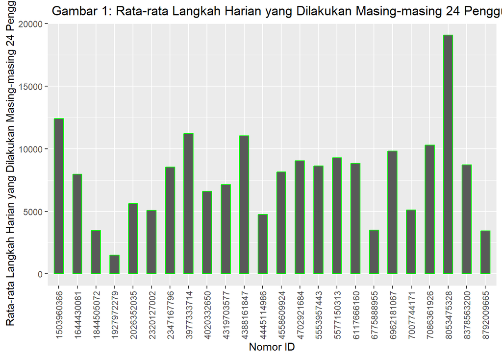

```r
ggplot(data = average_activity, aes(x = id, y = avg_daily_steps)) +
  geom_bar(stat = "identity", color = "green", width = .5) +
  labs(title = " Gambar 1: Rata-rata Langkah Harian yang Dilakukan Masing-masing 24 Pengguna",
       x = "Nomor ID",
       y = "Rata-rata Langkah Harian yang Dilakukan Masing-masing 24 Pengguna"
  ) + theme(axis.text.x = element_text(angle = 90, vjust = 0.5, hjust=1))
```

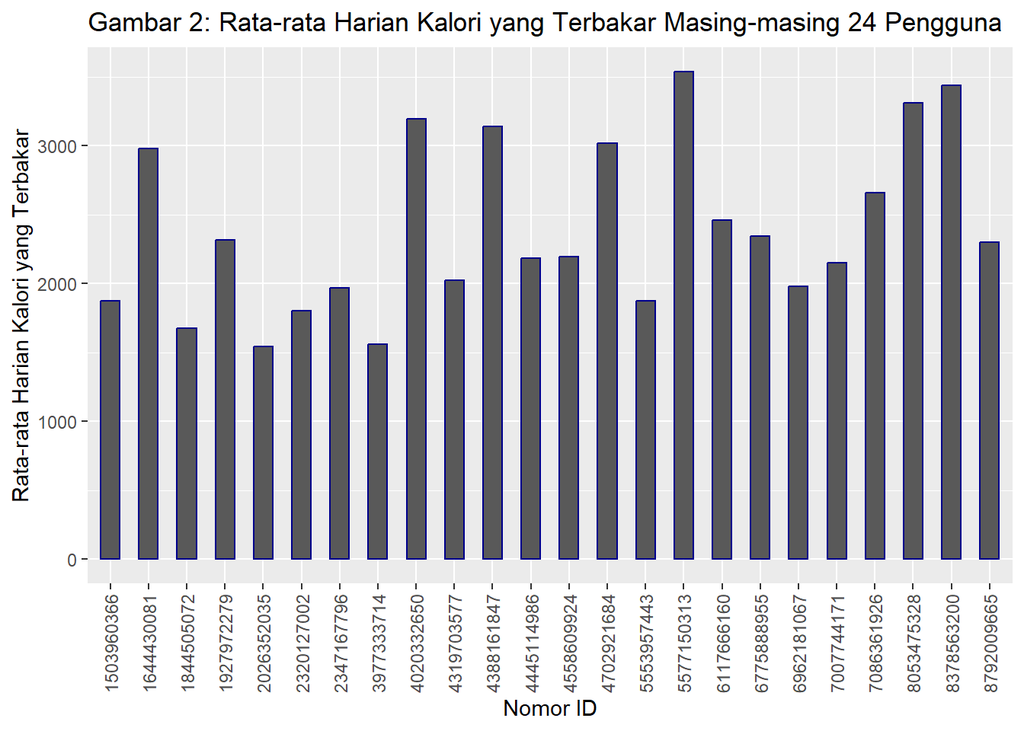

```r
ggplot(data = average_activity, aes(x = id, y = avg_daily_calories)) +
  geom_bar(stat = "identity", color = "darkblue", width =.5) +
  labs(title = "Gambar 2: Rata-rata Harian Kalori yang Terbakar Masing-masing 24 Pengguna",
       x = "Nomor ID",
       y = "Rata-rata Harian Kalori yang Terbakar"
  ) + theme(axis.text.x = element_text(angle = 90, vjust = 0.5, hjust=1))
```

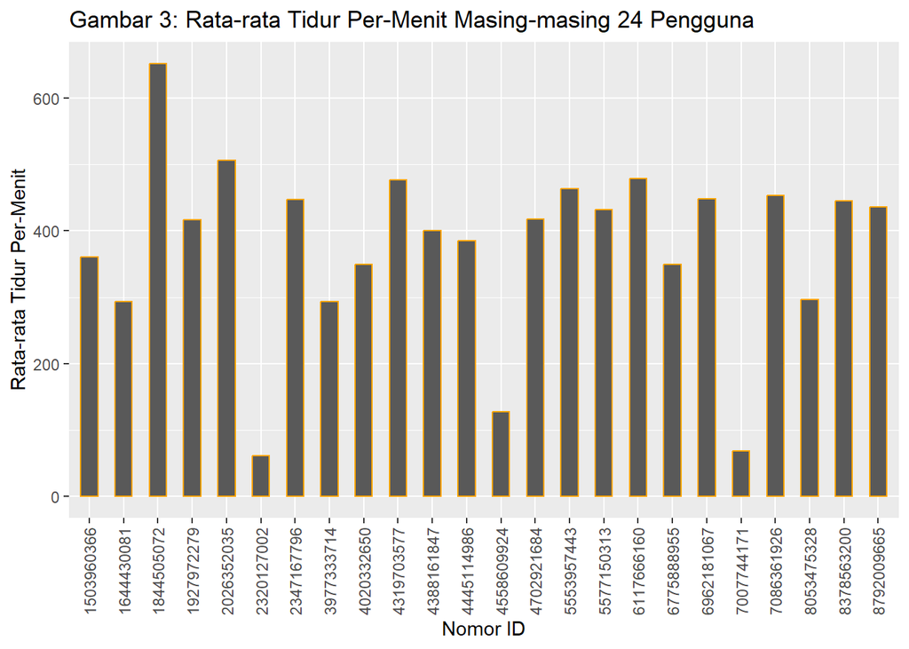

```r
ggplot(data = average_activity, aes(x = id, y = avg_sleep)) +
  geom_bar(stat = "identity", color = "orange", width =.5) +
  labs(title = "Gambar 3: Rata-rata Tidur Per-Menit Masing-masing 24 Pengguna",
       x = "Nomor ID",
       y = "Rata-rata Tidur Per-Menit"
  ) + theme(axis.text.x = element_text(angle = 90, vjust = 0.5, hjust=1))
```

Selanjutnya saya ingin mengkonfirmasi hipotesis bahwa lebih banyak kalori yang dibakar seiring dengan bertambahnya jumlah langkah:

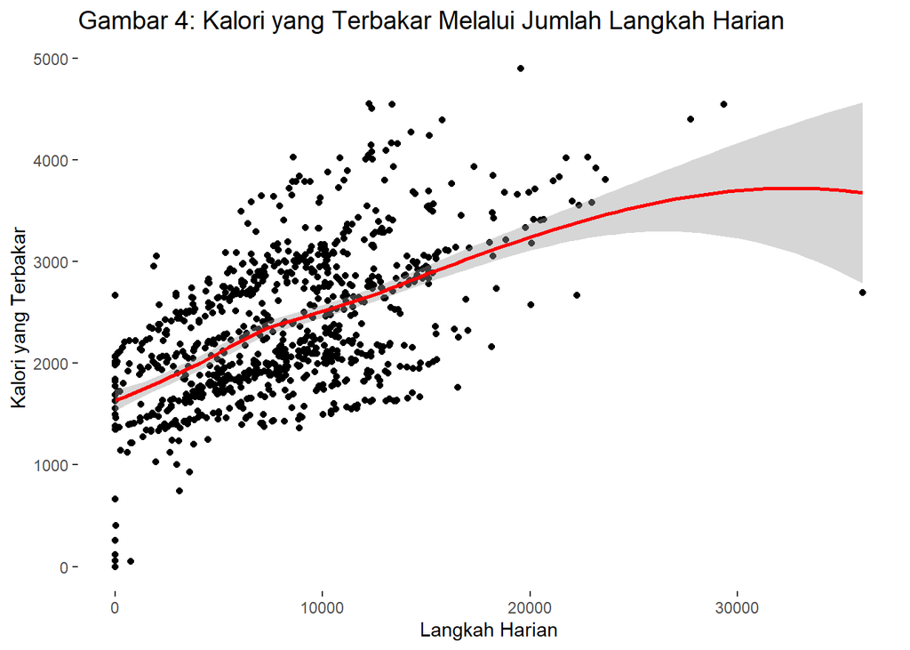

```r
activity %>%
  ggplot(aes(x = TotalSteps, y = Calories))+
  geom_jitter() +
  geom_smooth(method = "loess", color = "red") +
  labs(title = "Gambar 4: Kalori yang Terbakar Melalui Jumlah Langkah Harian",
    x = "Langkah Harian",
    y = "Kalori yang Terbakar") +
  theme(panel.background = element_blank(),
        plot.title = element_text( size=14))
```

Berdasarkan gambar 4 di atas, seperti yang saya harapkan, pasti ada hubungan antara kalori yang terbakar dan jumlah langkah yang dilakukan setiap hari. Kalori yang terbakar biasanya meningkat seiring dengan meningkatnya jumlah langkah harian yang dilakukan.

Dan saya ingin melihat apakah ada hubungan antara total tidur per menit dan jumlah langkah yang diambil setiap hari.

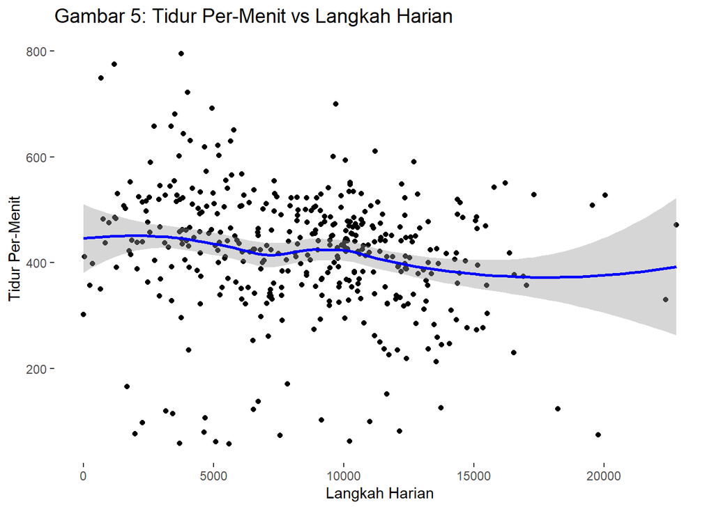

```r
activity_plus_sleep%>%
  ggplot(aes(x = total_steps,
             y = total_minutes_asleep)) +
  geom_jitter() +
  geom_smooth(method = "loess", color = "blue") +
  labs(title = "Gambar 5: Tidur Per-Menit vs Langkah Harian",
       x = "Langkah Harian",
       y = "Tidur Per-Menit") +
  theme(panel.background = element_blank(),
        plot.title = element_text(size=14))
```

Berdasarkan gambar 5 di atas tidak ada hubungan antara berapa banyak tidur yang didapat pengguna dengan berapa banyak langkah yang mereka ambil pada hari tertentu. Plot ini menyiratkan bahwa lamanya waktu tidur pengguna tidak selalu berkorelasi dengan jumlah langkah yang dilakukan pada hari tertentu.

Untuk mendapatkan gambaran tentang kerangka data aktivitas harian, saya akan memilih beberapa kolom dan merangkum datanya:

```r
activity %>%
  select(TotalSteps,
         Calories) %>%
  summary()
```

```
##    TotalSteps       Calories
##  Min.   :    0   Min.   :   0
##  1st Qu.: 3790   1st Qu.:1828
##  Median : 7406   Median :2134
##  Mean   : 7638   Mean   :2304
##  3rd Qu.:10727   3rd Qu.:2793
##  Max.   :36019   Max.   :4900
```

Beberapa grafik dibuat untuk meninjau bagaimana tingkat aktivitas yang berbeda (rendah, sedang, tinggi) yang diukur dalam hitungan menit mempengaruhi penggunaan kalori:

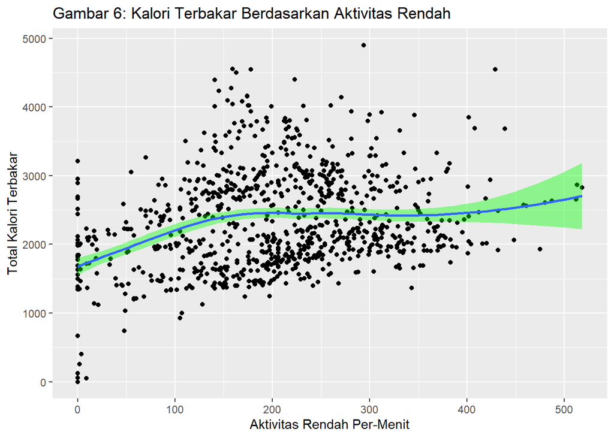

```r
ggplot(data = activity)+
  aes(x = LightlyActiveMinutes,
      y = Calories)+
  geom_point(color = "black")+
  geom_smooth(method = 'loess',fill = "green")+
  labs(x = "Aktivitas Rendah Per-Menit", y = "Total Kalori Terbakar",
       title = "Gambar 6: Kalori Terbakar Berdasarkan Aktivitas Rendah")
```

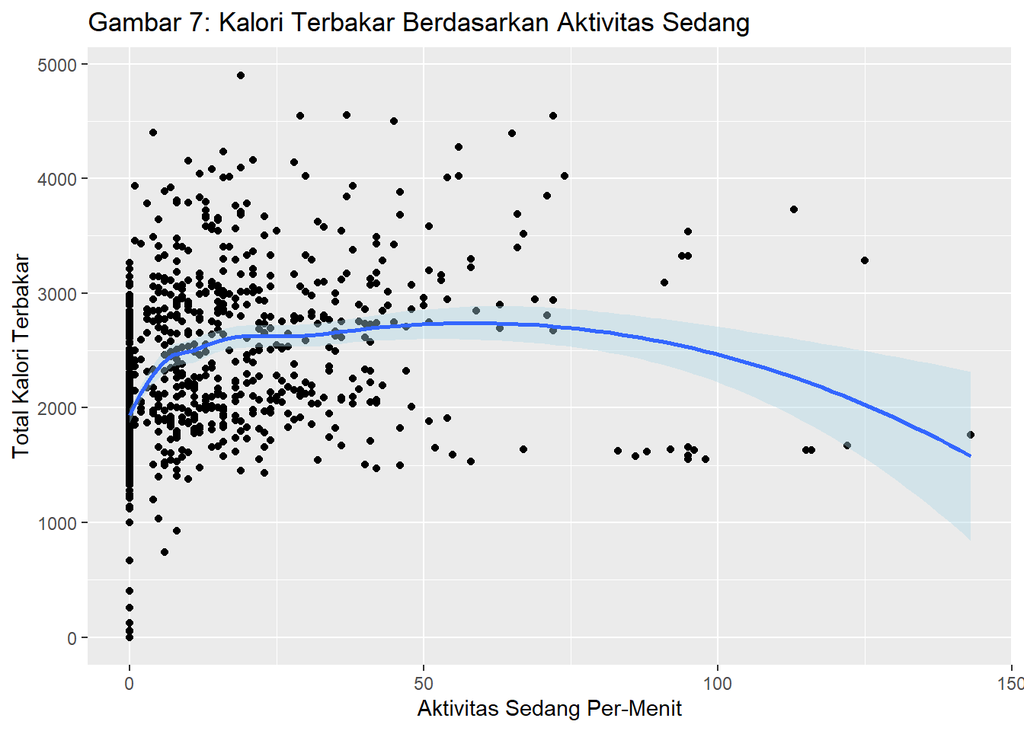

```r
ggplot(data = activity)+
  aes(x = FairlyActiveMinutes,
      y = Calories)+
  geom_point(color = "black")+
  geom_smooth(method = 'loess', fill = "lightblue")+
  labs(x = "Aktivitas Sedang Per-Menit", y = "Total Kalori Terbakar",
       title = "Gambar 7: Kalori Terbakar Berdasarkan Aktivitas Sedang")
```

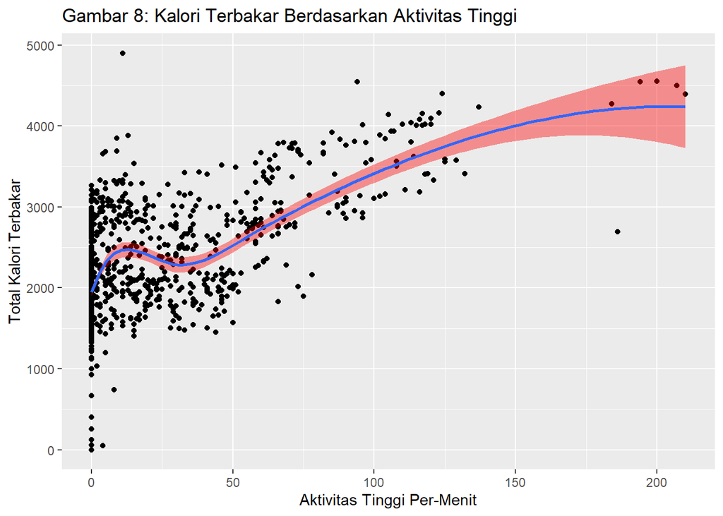

```r
ggplot(data = activity)+
  aes(x = VeryActiveMinutes,
      y = Calories)+
  geom_point(color = "black")+
  geom_smooth(method = 'loess', fill = "red")+
  labs(x = "Aktivitas Tinggi Per-Menit", y = "Total Kalori Terbakar",
       title = "Gambar 8: Kalori Terbakar Berdasarkan Aktivitas Tinggi")
```

Gambar 6 menunjukkan sulit membakar lebih dari 5000 kalori pada aktivitas rendah. Sebagian besar pengguna membakar 1200-4000 kalori dalam 100-300 menit aktivitas intensitas rendah.

Gambar 7 menunjukkan lebih sedikit orang aktif lebih dari 1 jam. Aktivitas medium kebanyakan berlangsung dalam 50 menit.

Gambar 8 menunjukkan kalori terbakar cepat pada aktivitas tinggi. Beberapa pengguna mampu membakar 1500-3500 kalori dalam <50 menit. Cara pembakaran berbeda, misalnya, bekerja di konstruksi selama 200 menit hanya membakar 1000 kalori ekstra. Hubungan positif ini menunjukkan semakin lama aktivitas tinggi, semakin banyak kalori terbakar.

Jika dilihat data ini dalam bentuk tabel:

```r
activity %>%
  select(LightlyActiveMinutes,
         FairlyActiveMinutes,
         VeryActiveMinutes,
         SedentaryMinutes) %>%
  summary()
```

```
##  LightlyActiveMinutes FairlyActiveMinutes VeryActiveMinutes SedentaryMinutes
##  Min.   :  0.0        Min.   :  0.00      Min.   :  0.00    Min.   :   0.0
##  1st Qu.:127.0        1st Qu.:  0.00      1st Qu.:  0.00    1st Qu.: 729.8
##  Median :199.0        Median :  6.00      Median :  4.00    Median :1057.5
##  Mean   :192.8        Mean   : 13.56      Mean   : 21.16    Mean   : 991.2
##  3rd Qu.:264.0        3rd Qu.: 19.00      3rd Qu.: 32.00    3rd Qu.:1229.5
##  Max.   :518.0        Max.   :143.00      Max.   :210.00    Max.   :1440.0
```

Tabel ini menunjukkan bahwa kolom aktivitas rendah per-menit dan sedentary menit menyumbang menit terbanyak yang dihabiskan oleh semua peserta. Dengan kata lain, kebanyakan orang menghabiskan waktu mereka dengan gaya hidup yang tidak banyak bergerak dibandingkan dengan gaya hidup yang agak aktif atau sangat aktif.

Saya juga melihat hari mana yang paling ‘aktif’ bagi pengguna dalam hal rata-rata tertinggi setiap hari:

```r
activity_plus_sleep %>%
  group_by(day_of_week) %>%
  drop_na() %>%
  summarize(mean_total_steps = mean(total_steps))
```

```
## # A tibble: 7 × 2
##   day_of_week mean_total_steps
##   <chr>                  <dbl>
## 1 Friday                 7901.
## 2 Monday                 9273.
## 3 Saturday               9871.
## 4 Sunday                 7298.
## 5 Thursday               8184.
## 6 Tuesday                9183.
## 7 Wednesday              8023.
```

Terlihat dengan jelas bahwa hari Sabtu memiliki jumlah langkah terbanyak diikuti oleh Senin dan Selasa, sedangkan hari Minggu memiliki jumlah langkah paling sedikit.

Untuk menunjukkan rata-rata kalori yang terbakar per jam setiap hari berikut visualnya:

```r
avg_calories_burned <- calories_burned_perhour  %>%
  group_by(day_of_week) %>%
  summarize(avg_burned = mean (calories))
head(avg_calories_burned)
```

```
## # A tibble: 6 × 2
##   day_of_week avg_burned
##   <chr>            <dbl>
## 1 Friday            97.8
## 2 Monday            97.1
## 3 Saturday          99.9
## 4 Sunday            94.3
## 5 Thursday          97.0
## 6 Tuesday           98.6
```

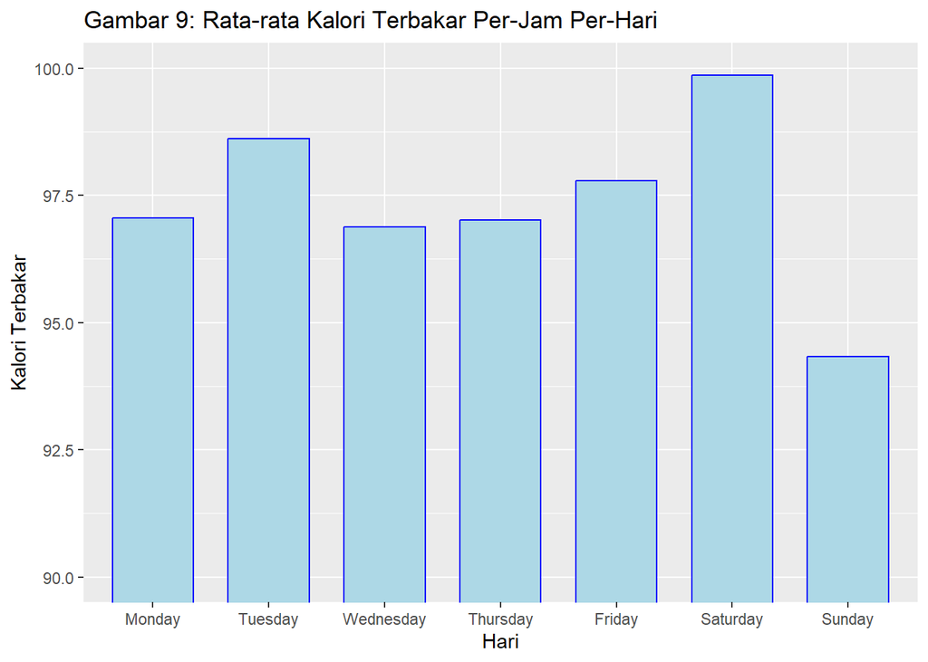

```r
ggplot(data = avg_calories_burned, aes(
  x = factor(day_of_week,levels = c("Monday", "Tuesday", "Wednesday", "Thursday", "Friday", "Saturday", "Sunday")),
  y = avg_burned)) +
  geom_bar(stat = "identity", color = "blue", fill = "lightblue", width = .70) +
  labs(title = "Gambar 9: Rata-rata Kalori Terbakar Per-Jam Per-Hari",
    x = "Hari",
    y = "Kalori Terbakar"
  ) +
  coord_cartesian(ylim=c(90,100))
```

Dari grafik batang di atas terlihat bahwa lebih banyak kalori yang dibakar per jam pada hari Sabtu, dengan paling sedikit kalori yang terbakar pada hari Minggu. Oleh karena itu, dapat disimpulkan bahwa peserta lebih aktif pada hari Sabtu dan paling sedikit aktif pada hari Minggu. Hal ini masuk akal karena kebanyakan orang tidak bekerja pada akhir pekan dan cenderung lebih sering berolahraga atau keluar rumah, dan pada hari Minggu biasanya merupakan hari istirahat bagi kebanyakan orang.

### **Insights**

Beberapa pola lain dapat terlihat dengan membandingkan berbagai parameter. Tetapi, berdasarkan pola yang terlihat dalam data Fitbit ini, dapat disimpulkan sebagai berikut:

• Data ini tidak cukup untuk memberikan rekomendasi tepat tentang cara Bellabeat memodifikasi produk mereka untuk wanita. Informasi demografi, terutama data gender, akan sangat membantu.

• Beberapa data kehilangan informasi seperti ID, catatan berat badan, dan langkah harian. Oleh karena itu, pengumpulan data harus dilakukan melalui perangkat Bellabeat.

• Laporan ini menunjukkan bahwa aktivitas fisik seperti berjalan, lari, dan berolahraga penting untuk gaya hidup sehat. Ini membantu membakar lebih banyak kalori dan menjaga kebugaran.

• Orang cenderung memilih gaya hidup kurang aktif, kecuali ada dorongan fisik seperti bunyi atau getaran dari aplikasi yang mendorong mereka untuk tetap aktif.

• Rata-rata, peserta membakar sekitar 2000 kalori sehari terlepas dari tingkat aktivitas.

• Pengeluaran kalori meningkat seiring dengan jumlah langkah. Ini berlaku bahkan jika orang melakukan aktivitas tingkat rendah, meskipun sangat sulit untuk membakar lebih dari 5000 kalori.

• Umumnya, orang paling aktif pada hari Sabtu dan paling tidak aktif pada hari Minggu.

### **Recommendations**

Saya akan menggunakan wawasan dari botol air Bellabeat untuk meningkatkan kampanye pemasaran. Botol air ini memantau asupan air harian dengan teknologi pintar untuk memastikan pengguna tetap terhidrasi. Alat ini terhubung ke aplikasi Bellabeat untuk memantau tingkat hidrasi.

1. **Kolaborasi dan Kemitraan**: Bellabeat dapat menjalin kemitraan dengan organisasi atau komunitas kesehatan untuk memperluas jangkauan kampanye pemasaran. Dengan bekerja sama dengan ahli kesehatan, pelatih, atau influencer kesehatan, mereka dapat memberikan pengetahuan tambahan dan memberikan dorongan positif kepada pengguna untuk mengadopsi gaya hidup sehat.
2. **Kustomisasi dan Personalisasi**: Memungkinkan pengguna untuk menyesuaikan pengaturan dan tujuan mereka dalam aplikasi Bellabeat dapat meningkatkan keterlibatan. Fitur-fitur seperti pengaturan target pribadi, pengingat kustom, atau rekomendasi berdasarkan aktivitas sebelumnya dapat membantu pengguna merasa terhubung secara pribadi dengan produk dan aplikasi Bellabeat.
3. **Fokus pada Gaya Hidup Sehat**: Penting untuk mendorong dan memberikan kesempatan kepada masyarakat untuk mengadopsi gaya hidup sehat. Ini bisa dicapai dengan kampanye pemasaran yang menekankan elemen kunci seperti aktivitas fisik, hidrasi yang memadai, tidur yang cukup, dan memantau parameter penting seperti langkah, kalori, dan tidur.
4. **Edukasi tentang Pentingnya Minum Air**: Diperlukan upaya edukasi untuk menginformasikan masyarakat tentang pentingnya asupan air yang memadai setiap hari. Botol air cerdas seperti ‘Spring’ dapat membantu memantau dan memotivasi pengguna untuk tetap terhidrasi, terutama pada saat-saat kurang aktif.
5. **Insentif untuk Mendorong Partisipasi**: Memberikan insentif kepada pengguna botol air Spring yang mencapai target hidrasi dapat menjadi cara efektif untuk mendorong partisipasi aktif. Insentif ini dapat berupa poin atau diskon untuk produk lain, dan bisa disesuaikan dengan preferensi individu serta kondisi hari tertentu, seperti hari Minggu yang seringkali menjadi kesempatan untuk meningkatkan aktivitas dan hidrasi.